# [Cogsci] IntroStat 5 part2

### 5.1.2 Continuous random variables

연속형 확률 변수의 경우, 이산형과 같이 $P(X(\omega) = k)$를 구하는 것은 별 의미가 없습니다. 확률 변수가 가질 수 있는 값의 범위(range) 안에 너무 많은 값들이 존재하기 때문이지요.

예를 들어, 0과 1 사이에는 정수(이산형)는 하나도 없지만, 유리수는 1/2, 1/3... 등 무수히 많이 있습니다. 실수는 더욱 많을테지요. 이런 식으로 연속형의 경우, 확률 변수가 가질 수 있는 값이 너무 많아서 $P(X(\omega) = k)$는 모든 k에 대하여 0에 가까울 것입니다. 이런 경우에는 오히려 한 점(point) k가 아닌, 구간을 정해서 확률을 살펴보는 것이 훨씬 의미가 있습니다.

이러한 확률들은, 특정한 그림에서의 면적으로 계산될 수 있습니다. 이 그림은 **확률 밀도 함수(probability density function)**가 그리는 그림입니다. 확률 밀도 함수는 **확률 분포 함수**와 같은 종류라고 생각하시면 됩니다. 아까 본 확률 분포 함수는 X 라는 확률 변수가 가질 수 있는 값들이 띄엄 띄엄 놓여있었지만, 이제 나오는 확률 밀도 함수에서는 값들이 매우 촘촘하게 붙어 있겠지요. 아까 확률 분포가 하나의 함수였던 것 처럼, 확률 밀도도 하나의 함수입니다.

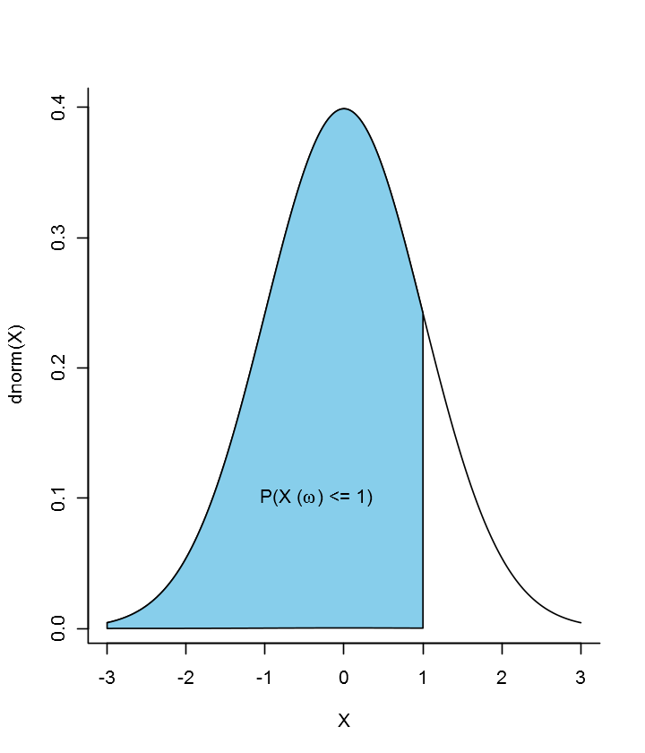

```r
options(repr.plot.heigt=1, repr.plot.width=6)
x <- seq(-3,3,0.01)
y1 <- dnorm(x,0,1)
y2 <- 0.5*dnorm(x,0,1)
x.shade <- seq(-3,1,0.01)
plot(x,y1,type="l",bty="L",xlab="X",ylab="dnorm(X)")
polygon(c(x.shade,rev(x.shade)),c(dnorm(x.shade,0,1),
                                  0.001*dnorm(rev(x.shade),0,1)),col="skyblue")
text(-0.35, 0.1, expression(paste("P(X (", omega, ") <= 1)")))
```

위에 보이는 파란색 면적이 곧 X라는 **continuous** random variable이 -$\infty$ 에서 1까지의 범위 안의 값을 가질 확률을 나타냅니다. 그러니까 저 면적을 구하면 해당 확률을 알 수 있습니다.

일반적으로 확률 밀도 함수는 $f$로 표기합니다. 만일 $f$ 라는 밀도 함수 아래의 면적이 확률을 나타낸다면, 확률의 정의에 따라 $\int_{-\infty}^\infty{f(x)dx}$ = 1이 될 것이고, 모든 x에 대해 $f(x) >= 0$입니다.

전체 영역의 면적이 1이기 때문에, $$P(X(\omega) <= b) = 1 - P(X(\omega)>b)$$ 역시 성립합니다.

[참고3] 확률 밀도/분포 함수와 누적 분포 함수

누적 분포 함수는 대문자 $F$로 표기합니다. 연속형 확률 변수의 경우, $F(b) = P(X(\omega)<=b)$ 이고, 계산 방법은 $\int_{-\infty}^b{f(x)dx}$ 입니다. 이산형 확률 변수의 경우에는 $\sum_{k<=b}{P(X(\omega)=k)}$로 구합니다.

이렇게만 써 놓으면 또 금방 이해가 안 가실 분도 있을 것 같아서, 밑에 CDF의 예시를 첨부합니다. 왼쪽은 연속형 확률 변수의 p.d.f이고, 오른쪽은 그 p.d.f 의 c.d.f 입니다. y축의 레이블을 보시면 p.d.f 는 density 라고 쓰여 있고, c.d.f 는 Fn(x) 라고 되어 있습니다(F(x)와 같은 말입니다. Fn은 function의 줄임말입니다).

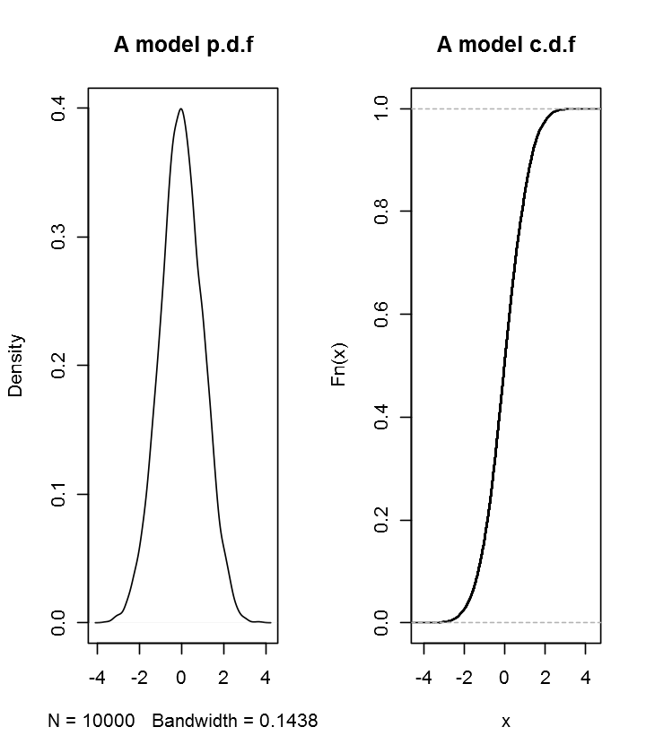

```r
options(repr.plot.heigt=2)
par(mfrow=c(1,2))
set.seed(1)
plot(density(rnorm(10000)), main="A model p.d.f")
set.seed(1)
plot(ecdf(rnorm(10000)), main="A model c.d.f")
```

그러니까, c.d.f는 -$\infty$ 부터 확률 변수 X의 특정 값 b 까지의 범위 안에 있는 값들이 가지는 확률들을 더하는 함수입니다. F(1) 라고 하면, X가 $-\inf$ 부터 1 까지 무수히 많은 가능한 값들의 확률을 더한 값인 셈입니다. 이를 통해서는 보통 quantile을 확인하곤 합니다. 책에도 보면 *Quantiles of a continuous random variable* 이라는 제목 아래에 그 내용이 나와 있습니다.

c.d.f의 역함수 값으로 quantile을 찾습니다. 예를 들어 F(k) 값이 0.7이라고 하면, X 라는 연속확률변수의 값 k의 quantile이 0.7이라는 이야기입니다. 곧 k는 가능한 X의 값들 중에 상위 30%라는 의미입니다.

그러면 반대로, 가능한 X의 값들 중에 상위 30%에 해당하는 값을 찾고 싶다고 해 봅시다. p.d.f 로는 이를 구하기가 꽤 어렵습니다. 이럴 때 $F^{-1}(0.7)$의 값은 곧 상위 30%에 해당하는 X의 가능한 값을 찾아주겠지요.

### 5.1.3 Sampling from a population

이 부분은 지난 번 스터디 때 이야기 한 것 같으니, 책을 가볍게 읽어 보시기 바랍니다. **identically distributed** 라는 표현과 **independent** 라는 표현의 의미를 잘 기억하시기 바랍니다.

sample 함수를 쓰시거든, i.i.d 를 성립하기 위해서는 replace=TRUE 라는 argument를 sample() 함수 내에 포함하셔야 하는 것을 기억하시기 바랍니다. 그 이유도 설명 드렸습니다. Example 5.4를 한 번 따라 해 보시면 좋겠네요.

### 5.1.4 Sampling distributions

통계치(statistic)는 random sample의 특징을 나타내는 수치들입니다. 표본 평균($\bar{X}$) 이나 표본 중간값 등이 있습니다. 이러한 통계치 역시 확률 변수입니다. 확률변수라는 것을 나타내기 위해서 대문자로 표기합니다. 통계치를 계산해내는 분포를 **표본 분포(sampling distribution)** 라고 합니다.

어떤 표본의 표본 평균은 다음과 같은 특징을 가집니다. $$E[\bar{X}] = \mu_{\bar{X}} = \mu~~and~~SD[\bar{X}] = \sigma_{\bar{X}} = \frac{\sigma}{\sqrt{n}}$$

스터디 때도 설명했지만, 표본 평균의 기대값은 표본 평균들의 평균이고, 이는 다시 전체 모집단의 평균과 같아집니다. 수학적 증명은 https://onlinecourses.science.psu.edu/stat414/node/167 를 참고하시기 바랍니다.

[참고] sampling method

제가 스터디 때 표본 평균의 기대값이 전체 모집단의 평균이기 때문에 표본의 크기 자체를 키울 것이 아니라 표본을 여러 개 모집해서 그 표본들의 평균을 살펴보는 것이 모집단의 평균을 더 잘 예측할 수 있는 방법이다 라고 말씀 드렸었습니다. 이에 **random sample** 일 때는 괜찮지 않나요? 라는 질문이 나왔습니다. 아마 제가 설문조사를 할 때 20대, 4-50대 등으로 연령을 기준 삼아서 sample을 모집하는 예를 들어서 그런 질문이 나온 것 같습니다.

일반적으로 simple random sampling을 많이 합니다. simple random sampling은 아래의 특징들을 만족하는 경우를 말합니다.

$$\begin{aligned}&The~population~consists~of~N~objects.\\ &The~sample~consists~of~n~objects.\\ &If~all~possible~samples~ of~ n ~objects ~are ~equally ~likely ~to ~occur,\\ &the ~sampling~ method~ is ~called ~simple ~random ~sampling.\end{aligned}$$

돈과 인력이 한정되어 있기 때문에 많은 경우 sampling은 한 번만 하는 경우가 많습니다. 신문에 나오는 설문조사등을 살펴봐도 1,500명 정도가 응답한 설문조사의 결과가 대한민국 국민이라는 모집단의 특성을 예측하는 데 사용되고는 하지요.

그러나 이는 저 위에서 말했듯이, 그러한 설문조사의 결과가 정확하게 대한민국 국민이라는 모집단을 대상으로 한 조사의 결과와 일치한다라는 뜻이 아니라, 같은 크기의 다른 표본을 통해 얻은 결과와 해당 표본을 통해 얻은 결과가 *같은 확률로* 나타날 것이기 때문에 해당 표본의 평균이 같은 크기의 다른 표본의 평균보다 모집단의 평균을 예측하는 정도가 떨어지지 않는다 정도의 의미를 가집니다. 이후에 confidence interval(7장)에서 이와 관련된 내용을 더 다룰 겁니다.

결국 simple random sampling의 경우이건 아니건, sampling을 여러 번 하지 않고 한 번만 하는 건 "괜찮다" 라기 보다는 여러 번 하기에 제약 조건이 많기 때문에 택하는 방법이라고 생각하시면 될 것 같습니다.

```r
# example: The expected value of the sample mean is equal
# to the mean of the population
population <- c(3,5,6)
sample1 <- c(3)
sample2 <- c(5)
sample3 <- c(6)
sample4 <- c(3,5)
sample5 <- c(3,6)
sample6 <- c(5,6)

## The mean of the population
mean(population)

## The mean of the sample means
(mean(sample1)+mean(sample2)+mean(sample3)+mean(sample4)+
mean(sample5)+mean(sample6))/6
```

4.66666666666667

4.66666666666667